# Forecast of Kelana Jaya LRT Ridership

Ang Jia Yi

2024-12-07

# Data Import

```r
# Import dataset and convert into time series data
excel <- read.csv("C:/Users/User/Desktop/Data/LRT KJL Monthly Ridership Dataset.csv")
data <- ts(excel[,-1],start=c(2019,1),frequency=12)
```

# Data Visualization

This section presents visualizations of the raw data of monthly ridership for LRT Kelana Jaya line.

## Overview

To obtain the general trend of LRT Kelana Jaya across the years:

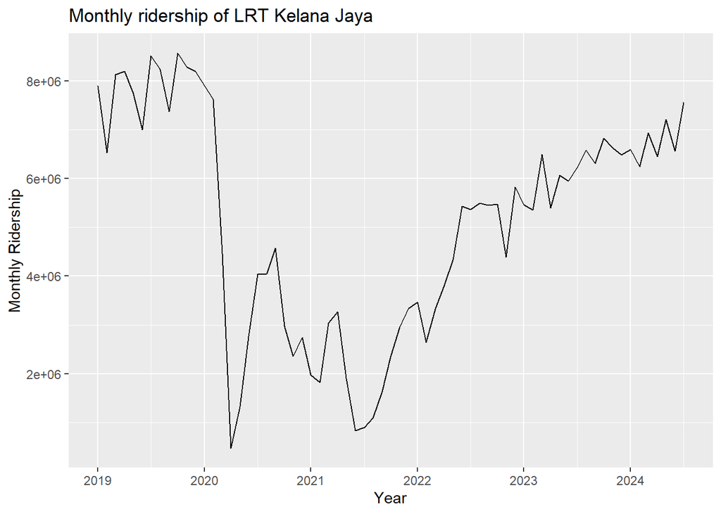

```r
autoplot(data) +
  labs(y = "Monthly Ridership",
       x = "Year",
       title = "Monthly ridership of LRT Kelana Jaya")
```

**Cyclical**

- Does not exhibit cyclical pattern.

**Seasonality**

- Does not show clear seasonality, except for some peaks and troughs that seem to be repeating at regular intervals before 2020 and after
- Could be signs of seasonality, but more data is needed to confirm its presence.

## Seasonal

A more detailed view of how the ridership behaves across months and between years, as well as to check for the presence of seasonality.

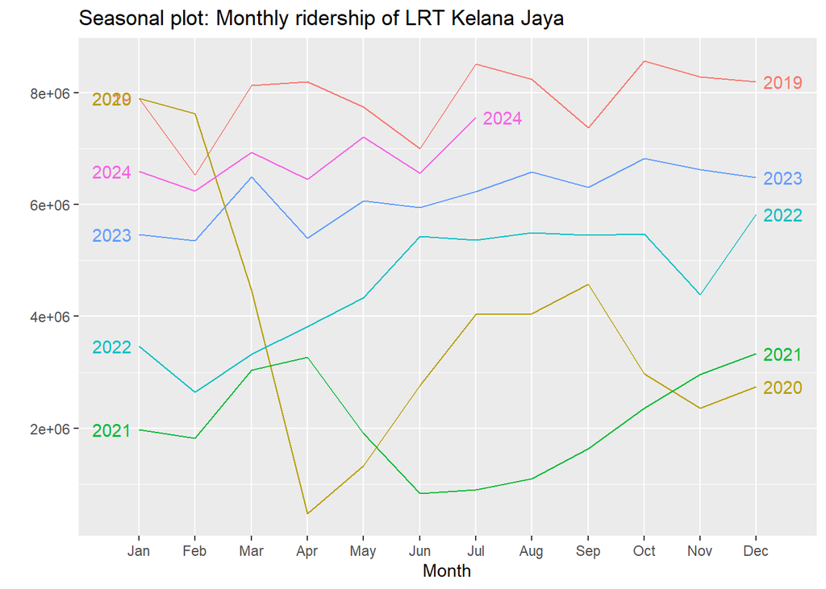

```r
ggseasonplot(data, year.labels = T, year.labels.left = T) +
  labs(title = "Seasonal plot: Monthly ridership of LRT Kelana Jaya")
```

- Does not display a consistent and similar pattern across all years due to COVID-19, hence it is unlikely for the whole dataset to exhibit seasonality pattern.
- However, the plots for 2019, 2023 and 2024 display some similarities in their peaks and troughs.
- Despite the similarities, the timing of peaks and troughs is not strictly regular, which may suggest that the series is influenced by irregular factors rather than a true seasonal componentsuch as changes in public transport policies or temporary shifts in commuter behaviour.
- For now, the data does not show strong evidence of seasonality.

## Seasonally adjusted

The seasonally adjusted data is obtained and plotted using STL decomposition to have a greater look on the underlying trend after factoring out the seasonal effects.

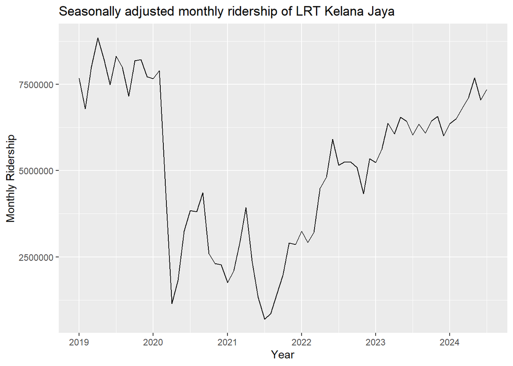

```r
# STL decomposition and plot the seasonally adjusted data
KJL.stl <- stl(data, s.window = "periodic")
autoplot(seasadj(KJL.stl)) +
  labs(y = "Monthly Ridership",
       x = "Year",
       title = "Seasonally adjusted monthly ridership of LRT Kelana Jaya")
```

- The seasonally adjusted plot generally follows a similar trend as the time plot.
- Since the seasonally adjusted plot highlights the underlying trend without seasonal effects, and it is generally similar to the time plot, hence this indicates the seasonal component has a minor effect on the ridership of LRT Kelana Jaya line.
- The ridership is more likely influenced by external factors such as the COVID-19 outbreak and implementations of MCO.

# Pre-Process Data

Since our goal is to forecast the monthly ridership of LRT Kelana Jaya for the next 2 years from July 2024, which currently there are rarely any COVID-19 cases, hence the data before June 2021 is irrelevant to our forecast goal as it includes the effect of MCO due to high volume of COVID-19 cases. Hence, the time span chosen as our full dataset to forecast the future monthly ridership is June 2021 to July 2024.

```r
KJL <- window(data, start = c(2021,6))
```

# Partition Series

The full dataset is partitioned into training and test sets.

|  | Training Set | Test set |
| --- | --- | --- |
| Time period | June 2021 to December 2023 | January 2024 to July 2024 |
| Number of observations | 31 | 7 |

```r
train <- window(KJL, end = c(2023,12))
test <- window(KJL, start = c(2024,1))
```

# Forecasting Methods/Models Identification

This section compare and evaluate four forecasting models chosen based on the characteristics of the test set data.

## Models Selection

**(1) Random Walk Drift Method**

- suitable as the test set data has a constant increasing trend that fluctuates randomly

```r
# (1) Random Walk Drift Method
fc1 <- rwf(train, drift = TRUE, h = length(test))
```

**(2) STL decomposition with ETS Model**

- The seasonally adjusted plot shows a relatively consistent random variation across the level of the series: *additive error*
- An evident upward trend that shows no signs of tapering off: *additive trend without damping*
- Since the data is seasonally adjusted, it does not pose seasonality: *none seasonality*
- ETS(A,A,N) model with both additive error and trend with no seasonality would optimally fit the seasonally adjusted data.

```r
#
fc2 <- stlf(train, etsmodel = "AAN", damped = FALSE, h = length(test))
```

**(3) ETS Model**

- Since the time plot and seasonally adjusted plot are similar in nature, combining no seasonality pattern was identified during the previous section.
- Hence, ETS(A,A,N) model with both additive error and trend with no seasonality would optimally fit the training set data.

```r
fc3 <- train %>%
  ets(model = "AAN", damped = FALSE) %>%
  forecast(h = length(test))
```

**(4) ETS Model Selected by R**

- An ETS model auto-selected by R is also included in the selection of models.
- The model chosen by R is ETS(M,A,N).

```r
fc4 <- train %>%
  ets(model = "ZZZ") %>%
  forecast(h = length(test))
```

## Parameter Estimation

```r
# Parameter Estimates and Initial Values for ETS model
summary(fc2)
```

```
##
## Forecast method: STL +  ETS(A,A,N)
##
## Model Information:
## ETS(A,A,N)
##
## Call:
## ets(y = na.interp(x), model = etsmodel, damped = FALSE, allow.multiplicative.trend = allow.multiplicative.trend)
##
##   Smoothing parameters:
##     alpha = 0.741
##     beta  = 0.0849
##
##   Initial states:
##     l = 341230.339
##     b = 349427.0257
##
##   sigma:  465462.9
##
##      AIC     AICc      BIC
## 921.3198 923.7198 928.4897
##
## Error measures:
##                     ME     RMSE      MAE       MPE    MAPE      MASE
## Training set -96570.92 434396.3 360980.9 -2.789462 9.55875 0.1593063
##                     ACF1
## Training set -0.04834932
##
## Forecasts:
##          Point Forecast   Lo 80   Hi 80   Lo 95   Hi 95
## Jan 2024        6619379 6022865 7215894 5707089 7531670
## Feb 2024        6049470 5275830 6823110 4866290 7232650
## Mar 2024        6862070 5916735 7807405 5416305 8307835
## Apr 2024        6478488 5362076 7594900 4771083 8185893
## May 2024        6996241 5707133 8285349 5024721 8967762
## Jun 2024        7217285 5752683 8681886 4977371 9457199
## Jul 2024        7218684 5575129 8862239 4705083 9732285
```

```r
summary(fc3)
```

```
##
## Forecast method: ETS(A,A,N)
##
## Model Information:
## ETS(A,A,N)
##
## Call:
## ets(y = ., model = "AAN", damped = FALSE)
##
##   Smoothing parameters:
##     alpha = 0.5585
##     beta  = 0.057
##
##   Initial states:
##     l = 564557.3871
##     b = 316779.6901
##
##   sigma:  577008.6
##
##      AIC     AICc      BIC
## 934.6389 937.0389 941.8089
##
## Error measures:
##                     ME     RMSE      MAE       MPE     MAPE      MASE
## Training set -110633.5 538497.1 404113.8 -3.648935 10.80032 0.1783415
##                     ACF1
## Training set -0.02845389
##
## Forecasts:
##          Point Forecast   Lo 80   Hi 80   Lo 95   Hi 95
## Jan 2024        6781330 6041864 7520796 5650414 7912246
## Feb 2024        6902517 6034183 7770851 5574514 8230520
## Mar 2024        7023704 6023020 8024389 5493289 8554119
## Apr 2024        7144891 6008027 8281756 5406207 8883576
## May 2024        7266079 5989036 8543121 5313010 9219147
## Jun 2024        7387266 5965979 8808553 5213595 9560936
## Jul 2024        7508453 5938844 9078062 5107943 9908963
```

```r
summary(fc4)
```

```
##
## Forecast method: ETS(M,A,N)
##
## Model Information:
## ETS(M,A,N)
##
## Call:
## ets(y = ., model = "ZZZ")
##
##   Smoothing parameters:
##     alpha = 0.7903
##     beta  = 0.0157
##
##   Initial states:
##     l = 513234.6867
##     b = 316779.0023
##
##   sigma:  0.1349
##
##      AIC     AICc      BIC
## 932.4459 934.8459 939.6159
##
## Error measures:
##                     ME     RMSE      MAE      MPE     MAPE      MASE       ACF1
## Training set -133263.7 553463.5 423678.9 -3.59584 10.67411 0.1869759 -0.2267493
##
## Forecasts:
##          Point Forecast   Lo 80    Hi 80   Lo 95    Hi 95
## Jan 2024        6836459 5654320  8018597 5028534  8644383
## Feb 2024        7088275 5530484  8646066 4705840  9470711
## Mar 2024        7340092 5448935  9231249 4447816 10232367
## Apr 2024        7591908 5388616  9795201 4222264 10961553
## May 2024        7843725 5339960 10347490 4014548 11672902
## Jun 2024        8095542 5297708 10893376 3816624 12374459
## Jul 2024        8347358 5258618 11436098 3623538 13071179
```

## Fitted Values

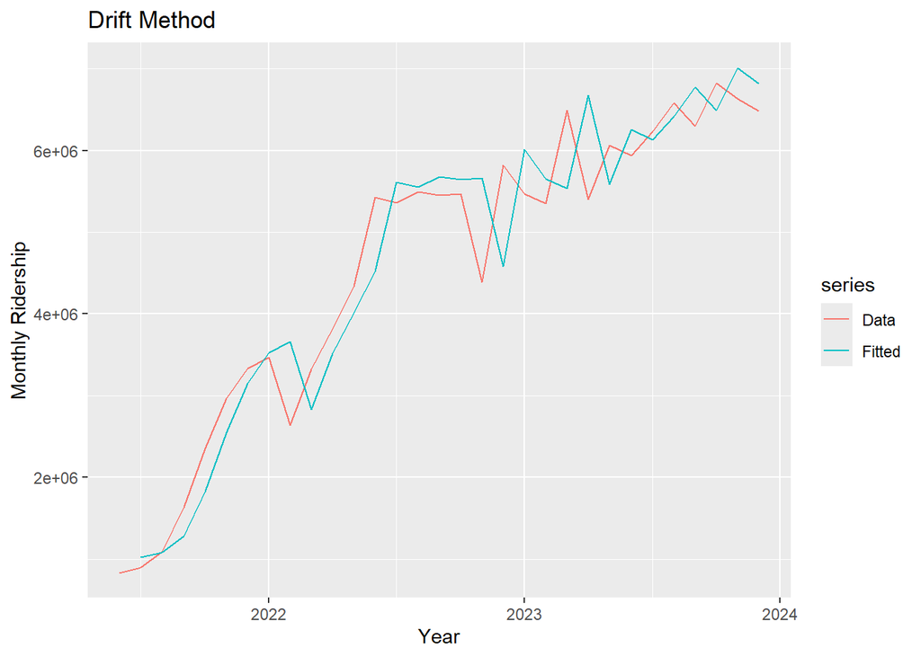

```r
# Plot training set data with fitted values from each methods
autoplot(train, series = "Data") +
  autolayer(fitted(fc1), series = "Fitted") +
  labs(title = "Drift Method",
       x = "Year",
       y = "Monthly Ridership")
```

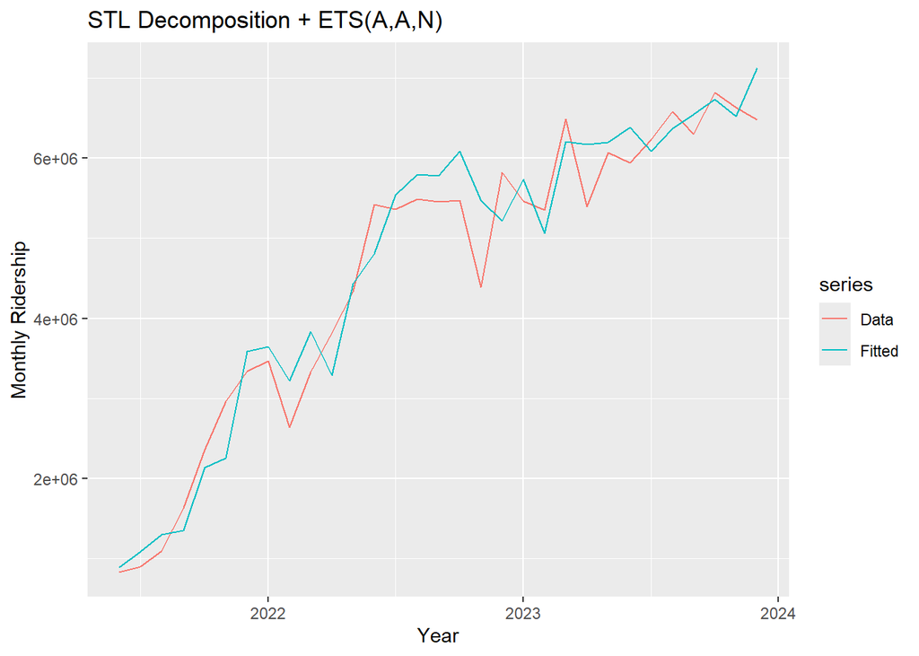

```r
autoplot(train, series = "Data") +
  autolayer(fitted(fc2), series = "Fitted") +
  labs(title = "STL Decomposition + ETS(A,A,N)",
       x = "Year",
       y = "Monthly Ridership")
```

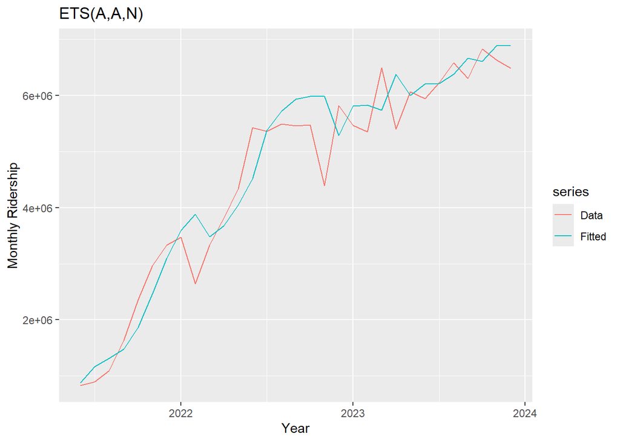

```r
autoplot(train,series = "Data") +
  autolayer(fitted(fc3), series = "Fitted") +
  labs(title = "ETS(A,A,N)",
       x = "Year",
       y = "Monthly Ridership")
```

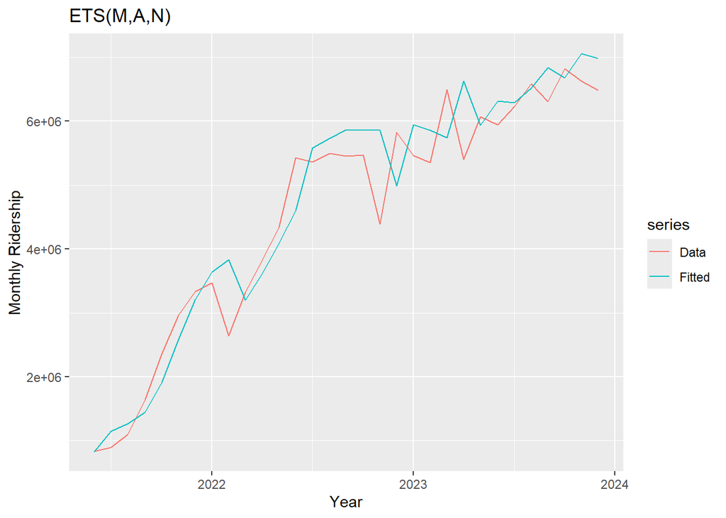

```r
autoplot(train, series = "Data") +
  autolayer(fitted(fc4), series = "Fitted") +
  labs(title="ETS(M,A,N)",
       x = "Year",
       y = "Monthly Ridership")
```

All of the four models are to capture the patterns of the training set data to a different extend.

## Residual Diagnostic Checks

To ensure there is no information left that should be used in computing the forecast, the forecast residuals must possess the following characeristics:

- residuals are uncorrelated.
- residuals have mean 0.
- residuals have constant variance

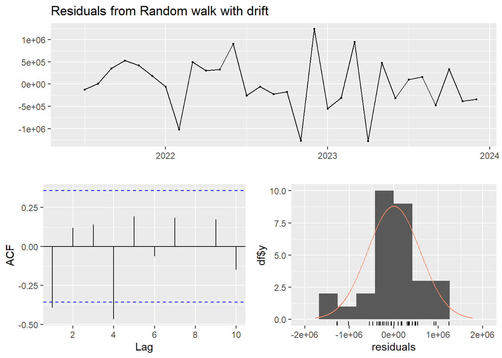

```
##
##  Ljung-Box test
##
## data:  Residuals from Random walk with drift
## Q* = 15.969, df = 6, p-value = 0.01392
##
## Model df: 0.   Total lags used: 6
```

```r
checkresiduals(fc1)
```

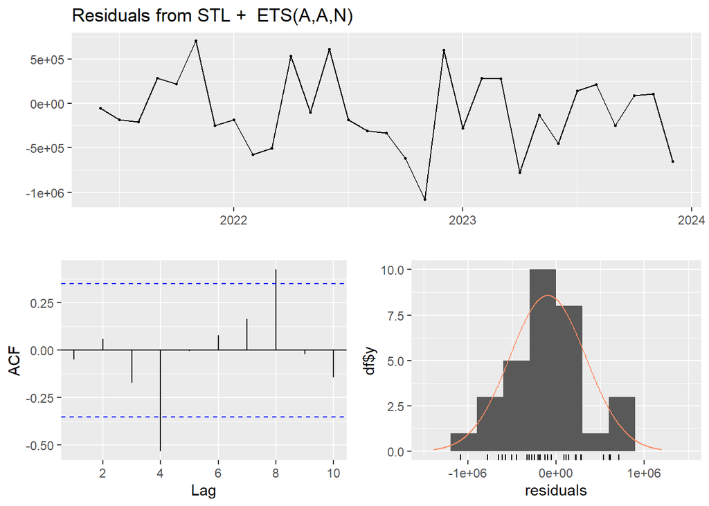

```
##
##  Ljung-Box test
##
## data:  Residuals from STL +  ETS(A,A,N)
## Q* = 12.325, df = 6, p-value = 0.05511
##
## Model df: 0.   Total lags used: 6
```

```r
checkresiduals(fc2)
```

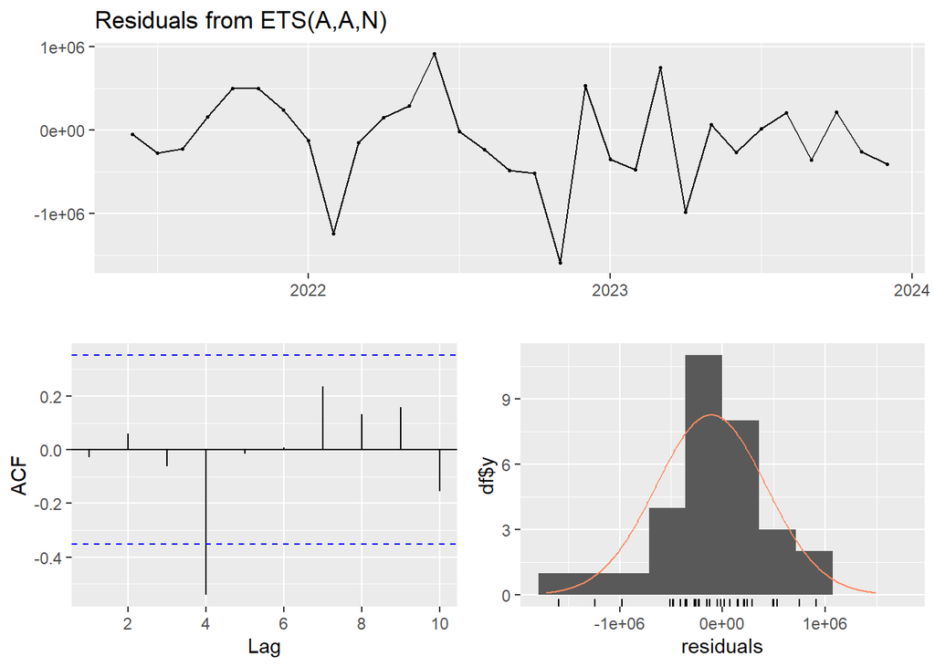

```
##
##  Ljung-Box test
##
## data:  Residuals from ETS(A,A,N)
## Q* = 11.421, df = 6, p-value = 0.07622
##
## Model df: 0.   Total lags used: 6
```

```r
checkresiduals(fc3)
```

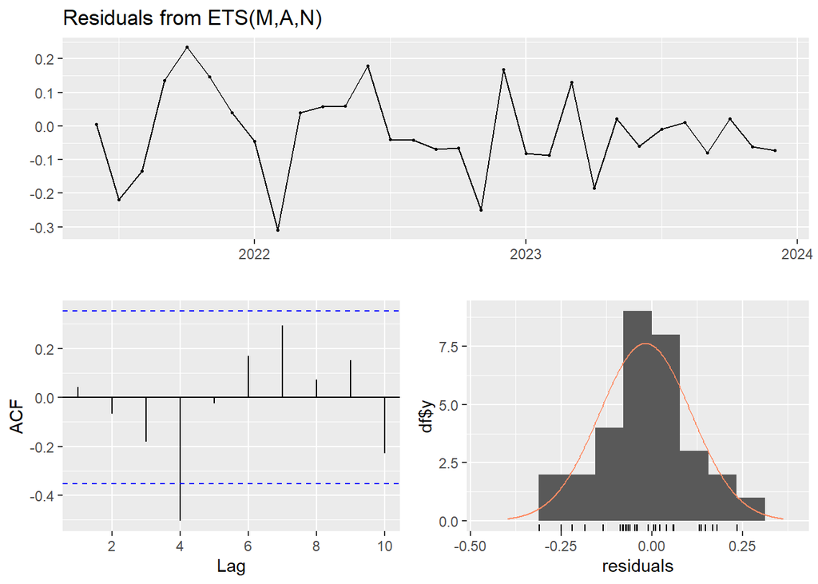

```
##
##  Ljung-Box test
##
## data:  Residuals from ETS(M,A,N)
## Q* = 12.28, df = 6, p-value = 0.05601
##
## Model df: 0.   Total lags used: 6
```

```r
checkresiduals(fc4)
```

### Ljung-box Test

There are a total of 6 lags used in this hypothesis testing. The hypotheses for the Ljung-Box test are as follows:

Null hypothesis, $H_0: \rho_1 = \rho_2 = ... = \rho_{10} = 0$

Alternative hypothesis, $H_1:$ At least one $\rho_k \neq 0,$ where $k = 0, 1, 2, ..., 6$

Since only the p-value of the *Method (1)* is smaller than $\alpha = 0.05$. Therefore, we have insufficient evidence to reject the null hypothesis at 5% significance level and concluded that there are no autocorrelations between the residuals for the remaining three models.

### Time Plot

Residuals of all four models have constant variance.

### ACF Graph

For a white noise series, we expect that 95% of the number of lags in the ACF to be within the confidence interval at a 5% significance level. With a total of 10 lags in the ACF plot, at least 9 lags should be bounded within the critical values for the residuals to be a white noise process. *Method (1)* and *Model (2)* both have 2 lags that have autocorrelations, which slightly exceeded our requirements.

### Histogram

Residuals of all four models are normally distributed with mean 0.

### Conclusion

*Model (3)* and *Model (4)* are preferred as the residuals are a white noise process, indicating most of the important information is used in computing the forecast.

## Goodness-of-Fit

```r
accuracy(fc1)
```

```
##                        ME     RMSE      MAE       MPE     MAPE      MASE
## Training set 2.328306e-10 580619.6 453521.2 0.1920488 10.78621 0.2001457
##                    ACF1
## Training set -0.3923148
```

```r
accuracy(fc2)
```

```
##                     ME     RMSE      MAE       MPE    MAPE      MASE
## Training set -96570.92 434396.3 360980.9 -2.789462 9.55875 0.1593063
##                     ACF1
## Training set -0.04834932
```

```r
accuracy(fc3)
```

```
##                     ME     RMSE      MAE       MPE     MAPE      MASE
## Training set -110633.5 538497.1 404113.8 -3.648935 10.80032 0.1783415
##                     ACF1
## Training set -0.02845389
```

```r
accuracy(fc4)
```

```
##                     ME     RMSE      MAE      MPE     MAPE      MASE       ACF1
## Training set -133263.7 553463.5 423678.9 -3.59584 10.67411 0.1869759 -0.2267493
```

## Forecast of Test Set Period

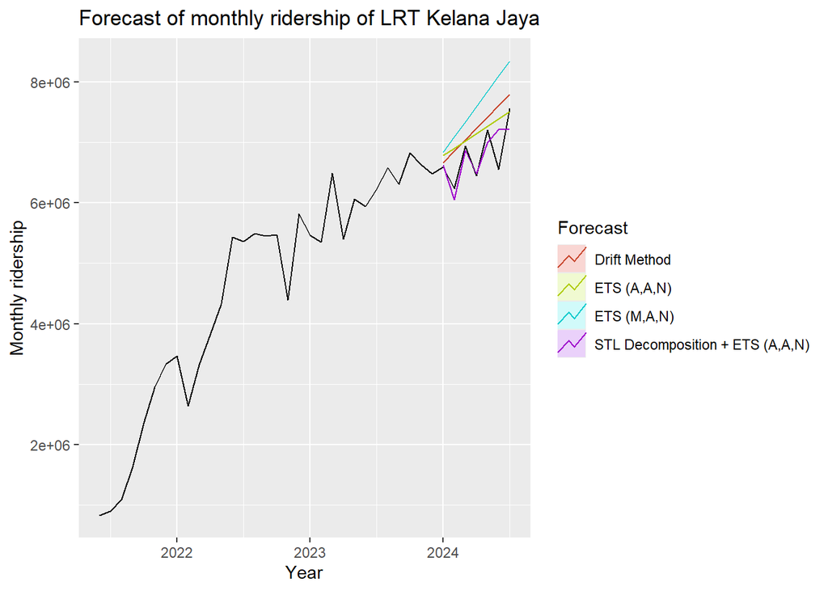

```r
# Forecast for the test set using each methods
autoplot(KJL) +
  labs(x = "Year",
       y = "Monthly ridership",
       title = "Forecast of monthly ridership of LRT Kelana Jaya") +
  autolayer(fc1, series = "Drift Method", PI = F) +
  autolayer(fc2, series = "STL Decomposition + ETS (A,A,N)",PI = F) +
  autolayer(fc3, series = "ETS (A,A,N)", PI = F) +
  autolayer(fc4, series = "ETS (M,A,N)", PI = F) +
  guides(colour = guide_legend(title = "Forecast"))
```

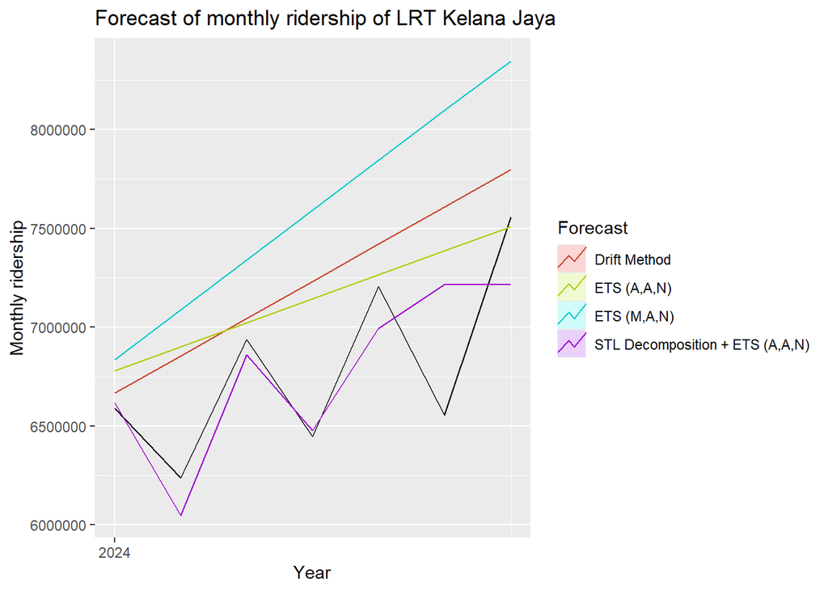

```r
# Shows only test set and forecast
autoplot(test) +
  labs(x = "Year",
       y = "Monthly ridership",
       title = "Forecast of monthly ridership of LRT Kelana Jaya") +
  autolayer(fc1, series = "Drift Method", PI = F) +
  autolayer(fc2, series = "STL Decomposition + ETS (A,A,N)",PI = F) +
  autolayer(fc3, series = "ETS (A,A,N)", PI = F) +
  autolayer(fc4, series = "ETS (M,A,N)", PI = F) +
  guides(colour = guide_legend(title = "Forecast"))
```

# Forecasting Performance Evaluation

## Traditional Approach

```r
acc_model1 <- accuracy(fc1,test)[2,]
acc_model2 <- accuracy(fc2,test)[2,]
acc_model3 <- accuracy(fc3,test)[2,]
acc_model4 <- accuracy(fc4,test)[2,]
```

```r
# Forecast Accuracy based on test set
cbind(acc_model1, acc_model2, acc_model3, acc_model4)
```

```
##              acc_model1    acc_model2    acc_model3    acc_model4
## ME        -4.420097e+05  1.306282e+04 -3.544547e+05 -8.014717e+05
## RMSE       5.646035e+05  3.025754e+05  4.890101e+05  8.991199e+05
## MAE        4.420097e+05  2.195588e+05  3.691253e+05  8.014717e+05
## MPE       -6.716325e+00  6.999851e-02 -5.497777e+00 -1.195877e+01
## MAPE       6.716325e+00  3.221632e+00  5.691837e+00  1.195877e+01
## MASE       1.950655e-01  9.689462e-02  1.629005e-01  3.537015e-01
## ACF1      -6.753686e-01 -5.674790e-01 -8.352902e-01 -3.219917e-01
## Theil's U  8.318344e-01  4.463396e-01  7.172925e-01  1.335923e+00
```

## Modern Approach: Time series cross validation

```r
# Let fets1 be the forecast function that produces forecasts for ETS(A,A,N) model
fets1 <- function(x,h){
  forecast(ets(x, model = "AAN",damped = FALSE),h = h)
}

# Let fets2 be the forecast function that produces forecasts for ETS(M,A,N) model
fets2 <- function(x,h){
  forecast(ets(x, model = "MAN", damped = FALSE), h = h)
}

# Obtain forecast errors
e1 <- tsCV(KJL, rwf, drift = TRUE, h = 4)
e2 <- tsCV(KJL, stlf, etsmodel = "AAN", damped = FALSE, h = 4)
e3 <- tsCV(KJL, fets1, h = 4)
e4 <- tsCV(KJL, fets2, h = 4)

# RMSE
sqrt(colMeans(e1^2, na.rm = TRUE))
```

```
##       h=1       h=2       h=3       h=4
##  617684.0  672731.0  893034.4 1096048.7
```

```r
sqrt(colMeans(e2^2, na.rm = TRUE))
```

```
##      h=1      h=2      h=3      h=4
## 430959.7 406444.1 394858.1 531253.8
```

```r
sqrt(colMeans(e3^2, na.rm = TRUE))
```

```
##       h=1       h=2       h=3       h=4
##  585277.9  717759.8  958043.1 1206587.9
```

```r
sqrt(colMeans(e4^2, na.rm = TRUE))
```

```
##       h=1       h=2       h=3       h=4
##  604545.6  734759.2 1024874.3 1290192.0
```

*Model (2)* also obtained the lowest RMSE using the time series cross-validation method, signifying that it was the best model with the highest out-of-sample forecast accuracy.

# Model Selection

Despite the residuals of *Model (2)* are statistically autocorrelated, but it is only borderline significant. On the other hand, the forecast accuracy of *Model (2)* is significantly higher than the remaining models. Hence, *Model (2)*, STL + ETS(A,A,N) is chosen as the optimal model for forecasting the monthly ridership on Kelana Jaya LRT line as it fits the historical data best and gives the most accurate forecast among all the models.

# Forecast Implementation

By using the selected model which is STL + ETS (A, A, N), the monthly ridership for Kelana Jaya Line if forecasted for the future 24 months.

```r
# Re-estimating Parameters and Initial Values
fc5 <- stlf(KJL, etsmodel = "AAN", damped = FALSE, h = 24, level = 95)
summary(fc5)
```

```
##
## Forecast method: STL +  ETS(A,A,N)
##
## Model Information:
## ETS(A,A,N)
##
## Call:
## ets(y = na.interp(x), model = etsmodel, damped = FALSE, allow.multiplicative.trend = allow.multiplicative.trend)
##
##   Smoothing parameters:
##     alpha = 0.6327
##     beta  = 0.0765
##
##   Initial states:
##     l = 407544.5331
##     b = 339879.1833
##
##   sigma:  452300.1
##
##      AIC     AICc      BIC
## 1133.681 1135.556 1141.869
##
## Error measures:
##                     ME   RMSE      MAE       MPE     MAPE      MASE        ACF1
## Training set -84765.66 427833 336705.1 -2.575749 8.751569 0.1763443 -0.03738161
##
## Forecasts:
##          Point Forecast   Lo 95    Hi 95
## Aug 2024        7297953 6411461  8184445
## Sep 2024        7261258 6174467  8348049
## Oct 2024        7609417 6318596  8900237
## Nov 2024        7297836 5797712  8797961
## Dec 2024        7789120 6073668  9504572
## Jan 2025        7700794 5763625  9637963
## Feb 2025        7234851 5069416  9400286
## Mar 2025        8034615 5634317 10434912
## Apr 2025        7609177 4967439 10250914
## May 2025        8228717 5339019 11118415
## Jun 2025        8175778 5031681 11319876
## Jul 2025        8488501 5083656 11893345
## Aug 2025        8419955 4748118 12091793
## Sep 2025        8383260 4438285 12328235
## Oct 2025        8731419 4507266 12955571
## Nov 2025        8419838 3910570 12929107
## Dec 2025        8911122 4110899 13711344
## Jan 2026        8822796 3725879 13919712
## Feb 2026        8356853 2957597 13756109
## Mar 2026        9156617 3449467 14863766
## Apr 2026        8731179 2710670 14751688
## May 2026        9350719 3011470 15689967
## Jun 2026        9297780 2634495 15961066
## Jul 2026        9610503 2617960 16603045
```

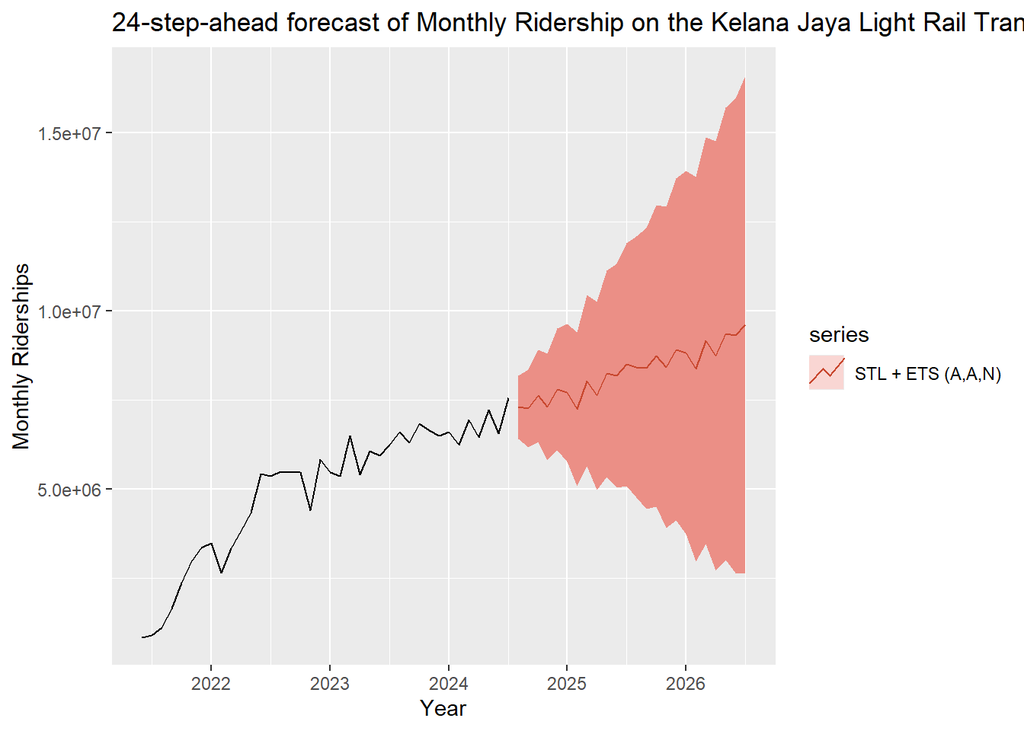

```r
# Plot full dataset with the forecasts
autoplot(KJL) +
  autolayer(fc5, series = "STL + ETS (A,A,N)", PI = TRUE) +
  labs(y = "Monthly Riderships",
       x = "Year",
       title = "24-step-ahead forecast of Monthly Ridership on the Kelana Jaya Light Rail Transit")
```

- The solid red line represents the median ridership, which shown the ridership will continue to rise for the future 24 months
- The shaded area represents the 95% forecast interval, which provide the range that may contain future observation within 95% probability.
- The forecast interval is widening over time, indicating there is enormous of uncertainty associated with the forecast.
- The upper bound of the forecast interval shows a rapid increase in ridership, which may be driven by factors such as increasing population in Klang Valley and increased adoption of public transport die to policy changes.
- The lower bound of forecast interval indicates the possibility of decrease in ridership growth. This could be due to more unexpected factors leading to the adoption of other transportation options.
- However, looking at the historical pattern that was steadily increasing, the decreasing pattern potrayed by the lower bound of the forecast interval deemed to be unreasonable.
- To conclude, the Malaysian government need to continuously monitor the actual ridership of LRT Kelana Jaya line to make adjustments accordingly, acknowledging the lower bound of the prediction interval.